# Stat 369 Lab 6: Autism trees

24 September 2020

This lab looks at data collected to try to detect autism spectrum disorder (ASD) biochemically. We use trees to detect ASD.

Submit a knitted html or pdf of your answer to Canvas.

## Tasks

#### Read in Data

```r
vnames <- read_csv("S1Dataset.csv",n_max=0)
autism<- read_csv("S1Dataset.csv",skip=2)
names(autism)<-names(vnames)

#note all SIB are NEU so recode SIB
OriginalGroup = autism$Group
autism$Group[autism$Group == "SIB"] = "NEU"
```

#### Task 1

1. Use `rpart()` to grow a tree that distinguishes the ASD and NEU groups, and give the confusion matrix and the proportion of people (from these two groups) correctly classified. Plot the tree (showing labels – make sure you set the margin in the plot call to make room for the labels).

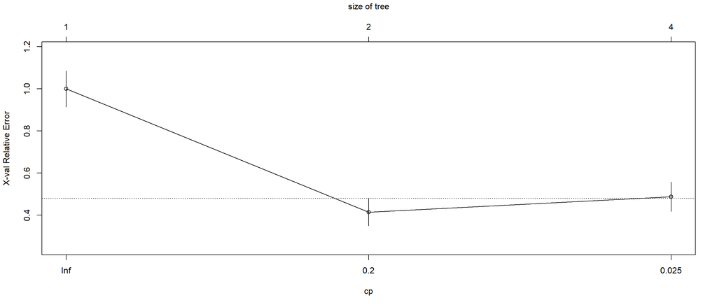

```r
#fit tree
autism.tree = rpart(Group~., data=autism)

#prune tree
plotcp(autism.tree)
```

```r
autism.tree = prune(autism.tree, cp=0.2)

#Confusion Matrix
y_pred_prob = predict(autism.tree)
s1 <- apply(y_pred_prob, 1, which.max)
y_pred = colnames(y_pred_prob)[s1]
conf_matrix = with(autism, table(actual=Group, predicted=y_pred))
conf_matrix
```

```
##       predicted
## actual ASD NEU
##    ASD  66  16
##    NEU  12 111
```

```r
#proportion of people correctly classified from ASD and NEU groups
number_of_people_in_both = sum(conf_matrix)
number_of_correct_pred_in_both = conf_matrix[1,1] + conf_matrix[2,2]
prop = number_of_correct_pred_in_both/number_of_people_in_both
prop
```

```
## [1] 0.8634146
```

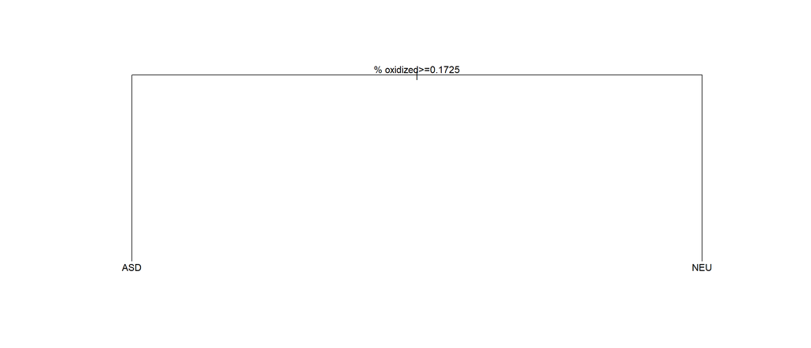

```r
#plot a tree
plot(autism.tree, margin=0.1);text(autism.tree)
```

Using the cp plot above, the tree has been pruned at cp=0.2 as this is the simplest model that is within one standard error of the on with the lowest error.

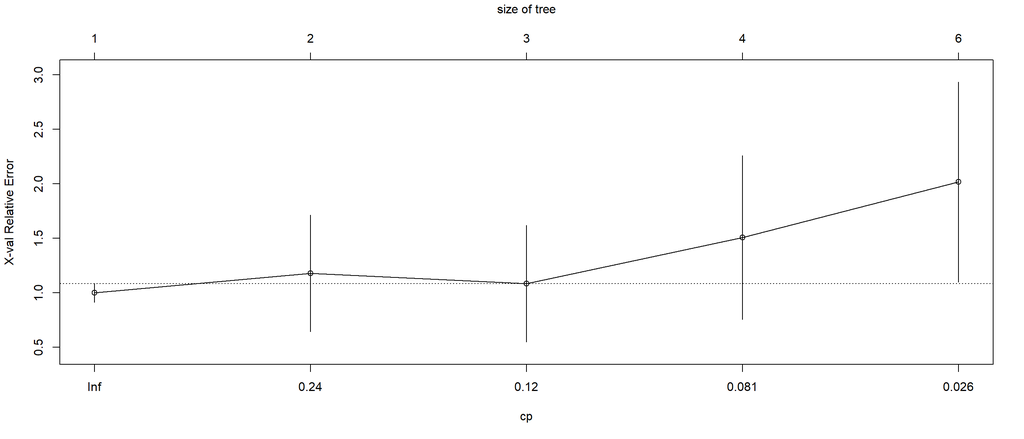

```r
prior = c(0.015, 0.985)
autism.tree_prior = rpart(Group~., data=autism,
                    parms=list(prior=prior))

#prune tree
plotcp(autism.tree_prior)
```

```r
autism.tree_prior = prune(autism.tree_prior, cp=0.24)

#Confusion Matrix
y_pred_prob = predict(autism.tree_prior)
max_idx <- apply(y_pred_prob, 1, which.max)
y_pred = colnames(y_pred_prob)[max_idx]
conf_matrix = with(autism, table(actual=Group, predicted=y_pred))
conf_matrix
```

```
##       predicted
## actual ASD NEU
##    ASD  30  52
##    NEU   0 123
```

```r
#proportion of people correctly classified from ASD and NEU groups
number_of_people_in_both = sum(conf_matrix)
number_of_correct_pred_in_both = conf_matrix[1,1] + conf_matrix[2,2]
prop = number_of_correct_pred_in_both/number_of_people_in_both
prop
```

```
## [1] 0.7463415
```

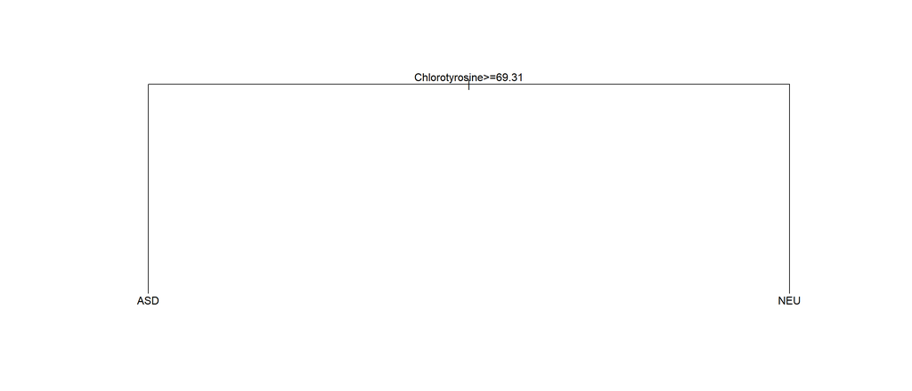

```r
#plot a tree
plot(autism.tree_prior, margin=0.1);text(autism.tree_prior)
```

3. Suppose that false negative classifications (missing ASD) are thought to be more important than false positive (suspecting ASD). Run `rpart()` with the `prior` argument as in the previous question and also with the `loss` argument saying that false negatives are 100 times as bad as false positives. Report the confusion matrix and the proportion of ASD and NEU groups correctly classified. Plot the tree. Did you get the result you expected?

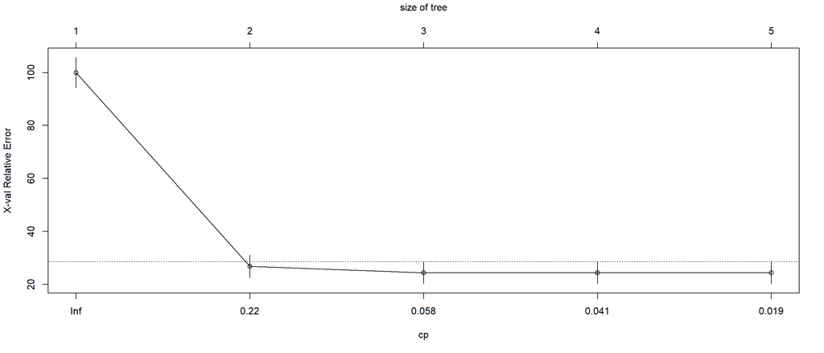

```r
prior = c(0.015, 0.985)
loss=matrix(c(0,1,100,0), nrow =2)
autism.tree_prior_loss = rpart(Group~., data=autism,
                    parms=list(prior=prior, loss=loss))

#prune tree
plotcp(autism.tree_prior_loss)
```

```r
autism.tree_prior_loss = prune(autism.tree_prior_loss, cp=0.22)

#Confusion Matrix
y_pred_prob = predict(autism.tree_prior_loss)
max_idx <- apply(y_pred_prob, 1, which.max)
y_pred = colnames(y_pred_prob)[max_idx]
conf_matrix = with(autism, table(actual=Group, predicted=y_pred))
conf_matrix
```

```
##       predicted
## actual NEU
##    ASD  82
##    NEU 123
```

```r
#proportion of people correctly classified from ASD and NEU groups
number_of_people_in_both = sum(conf_matrix)
number_of_correct_pred_in_both = conf_matrix[2,1]
prop = number_of_correct_pred_in_both/number_of_people_in_both
prop
```

```
## [1] 0.6
```

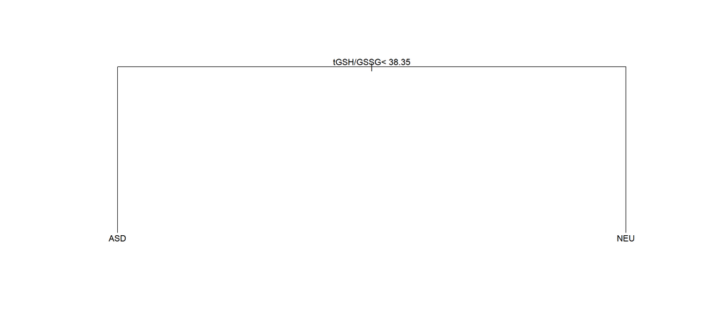

```r
#plot a tree
plot(autism.tree_prior_loss, margin=0.1);text(autism.tree_prior_loss)
```

4. Use this final tree to predict for the SIB group (all of whom are actually neurotypical). What proportion are correctly classified?

```r
autismSIBGroup = autism[OriginalGroup == "SIB", ]

sib_y_pred = predict(autism.tree_prior_loss, newdata=autismSIBGroup[, 2:ncol(autismSIBGroup)])

prop_correct = sum(sib_y_pred[,2])/nrow(sib_y_pred)
prop_correct
```

```
## [1] 0.9815399
```